# Q3_EDA and Modeling

Andrew Zinkan

8/25/2022

# EDA

*Q: Retail needs to worry about who has money to spend - what has changed about who is working and earning money?*

```r
load("../code/Q3_Data_Wrangling.RData")
sumtable(df)
```

Summary Statistics

| Variable | N | Mean | Std. Dev. | Min | Pctl. 25 | Pctl. 75 | Max |
| --- | --- | --- | --- | --- | --- | --- | --- |
| YEAR | 1034974 | 2019.619 | 0.636 | 2019 | 2019 | 2020 | 2021 |
| SERIAL | 1034974 | 34555.544 | 20187.543 | 1 | 17284 | 52105 | 70990 |
| HWTFINL | 1034974 | 2892.98 | 1618.284 | 156.706 | 1446.074 | 3970.614 | 26194.133 |
| CPSID | 1034974 | 20190900516117.1 | 7542208264.641 | 20171200000300 | 20190100276900 | 20200102624000 | 20210206898200 |
| PERNUM | 1034974 | 1.604 | 0.899 | 1 | 1 | 2 | 16 |
| WTFINL | 1034974 | 2947.176 | 1664.087 | 135.759 | 1470.887 | 4033.879 | 26194.133 |
| CPSIDP | 1034974 | 20190900516118.7 | 7542208264.613 | 20171200000302 | 20190100276901 | 20200102624002 | 20210206898201 |
| AGE | 1034974 | 44.245 | 11.443 | 25 | 34 | 54 | 65 |
| SEX | 1034974 |  |  |  |  |  |  |
| … 1 | 539028 | 52.1% |  |  |  |  |  |
| … 2 | 495946 | 47.9% |  |  |  |  |  |
| MARST | 1034974 |  |  |  |  |  |  |
| … 1 | 614331 | 59.4% |  |  |  |  |  |
| … 2 | 15531 | 1.5% |  |  |  |  |  |
| … 3 | 20010 | 1.9% |  |  |  |  |  |
| … 4 | 119985 | 11.6% |  |  |  |  |  |
| … 5 | 16509 | 1.6% |  |  |  |  |  |
| … 6 | 248608 | 24% |  |  |  |  |  |
| OCC | 1034974 | 3938.142 | 2687.546 | 0 | 1610 | 5620 | 9840 |
| IND | 1034974 | 6238.511 | 2721.617 | 0 | 4770 | 8190 | 9890 |
| indname | 300908 |  |  |  |  |  |  |
| … Agriculture, Forestry, Fishing, and Hunting, and Mining | 164574 | 54.7% |  |  |  |  |  |
| … Construction | 508 | 0.2% |  |  |  |  |  |
| … Transportation and Warehousing, and Utilities | 135826 | 45.1% |  |  |  |  |  |
| yearmo | 1034974 | 201968.58 | 62.397 | 201903 | 201908 | 202009 | 202102 |
| COVIDSTATUS | 1034974 |  |  |  |  |  |  |
| … post-covid | 457421 | 44.2% |  |  |  |  |  |
| … pre-covid | 577553 | 55.8% |  |  |  |  |  |
| Employed | 1034974 | 0.916 | 0.278 | 0 | 1 | 1 | 1 |
| Unemployed_experienced_worker | 1034974 | 0.047 | 0.211 | 0 | 0 | 0 | 1 |
| Unemployed_new_worker | 1034974 | 0.001 | 0.027 | 0 | 0 | 0 | 1 |
| Education | 1034974 |  |  |  |  |  |  |
| … college/associate/bachelor | 546479 | 52.8% |  |  |  |  |  |
| … doctorate | 24852 | 2.4% |  |  |  |  |  |
| … high school or lower | 323350 | 31.2% |  |  |  |  |  |
| … NA | 140293 | 13.6% |  |  |  |  |  |
| Workstatus | 1034974 |  |  |  |  |  |  |
| … full time | 769048 | 74.3% |  |  |  |  |  |
| … Not at work | 87168 | 8.4% |  |  |  |  |  |
| … part time | 178758 | 17.3% |  |  |  |  |  |
| Age_broad | 1034974 |  |  |  |  |  |  |
| … 25-35 | 289777 | 28% |  |  |  |  |  |
| … 36-45 | 265609 | 25.7% |  |  |  |  |  |
| … 46-55 | 258741 | 25% |  |  |  |  |  |
| … 56-65 | 220847 | 21.3% |  |  |  |  |  |

Im going to start out by adding a final variable `is_employed` which classifies EMPSTAT in (10, 12) as `employed` and EMPSTAT in (21,22) as `Unemployed`, and changing pre post to a bool value. Im also changing covide status to a `bool` value.

```r
df <- df %>% mutate(is_employed = case_when(EMPSTAT == 10 ~ '1',
                                            EMPSTAT == 12 ~ '1',
                                            TRUE ~ '0')) %>%
  mutate(is_employed = as.numeric(is_employed))

df$is_post <- (df$COVIDSTATUS == 'post-covid')
```

## High Level Frequency stats

Next I’m looking at some frequency stats to view the dispersion of our binary dependent variable. For this we notice that the majority class across the board is employed, and there is no large differences in employment among demographic traits, martial status, or industry that is clearly visible.

Because the following factor variables will be used as dummy variables down stream im going to be selective about which ones I keep. For example I want to avoid making a dummy variable where a single person is employed in a niche market as this adds more features with little importance.

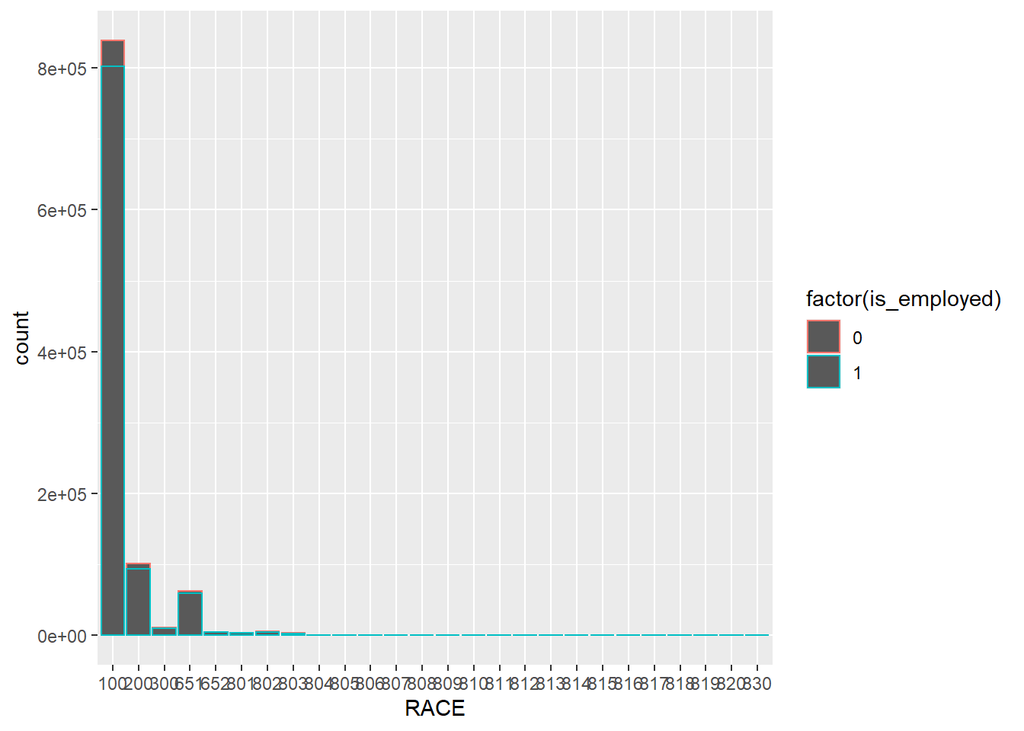

```r
ggplot(df, aes(x= RACE, color = factor(is_employed))) + geom_bar()
```

$Note:$ Looking at break out by race we have some very low count race’s that could add noise to our data and create many dummy variables.

As a retail business (retail market type undefined for this project) I would not be concerned so much with niche population demographics but rather the larger demographics that represent a larger group of individuals. Because retail focuses on a larger audience im going to reduce our sample to to look adjust the top 10 `RACE` demographics in terms of emploment population.

$Note:$ Filtering data for just our top ten most populated RACE categories.

```r
df %>%
  group_by(RACE) %>%
  summarise(rec_count = n()) %>%
  arrange(., desc(rec_count))
```

```
## # A tibble: 26 x 2
##    RACE  rec_count
##    <chr>     <int>
##  1 100      838648
##  2 200      101349
##  3 651       62407
##  4 300       11637
##  5 802        5409
##  6 652        4612
##  7 801        4072
##  8 803        3155
##  9 805         745
## 10 804         722
## # ... with 16 more rows
```

```r
df <- df %>%
  filter(RACE == c(100,200,300,651,802,652,801,803,805,804))
```

Looking at employment by industry

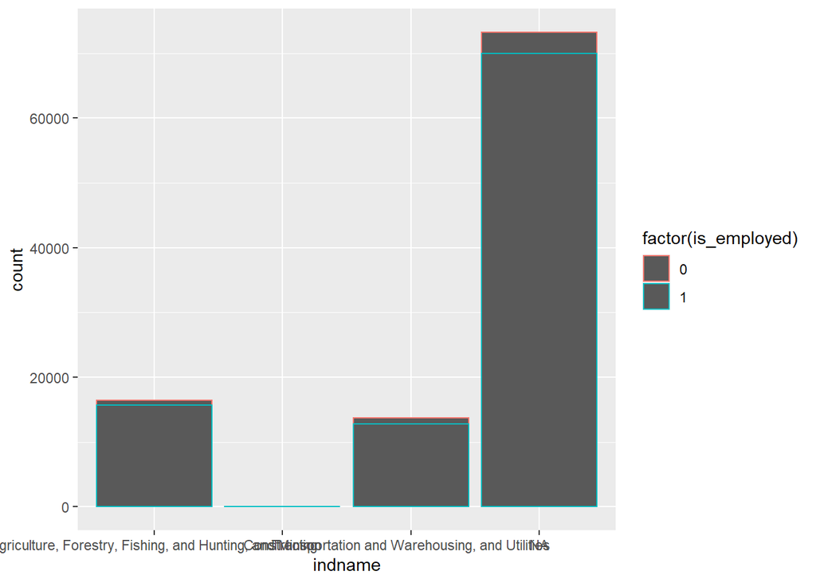

```r
ggplot(df, aes(x= indname, color = factor(is_employed))) + geom_bar()
```

$Note:$: Construction sector have very few employees, so im going to eliminate this industry from the sample to reduce noise.

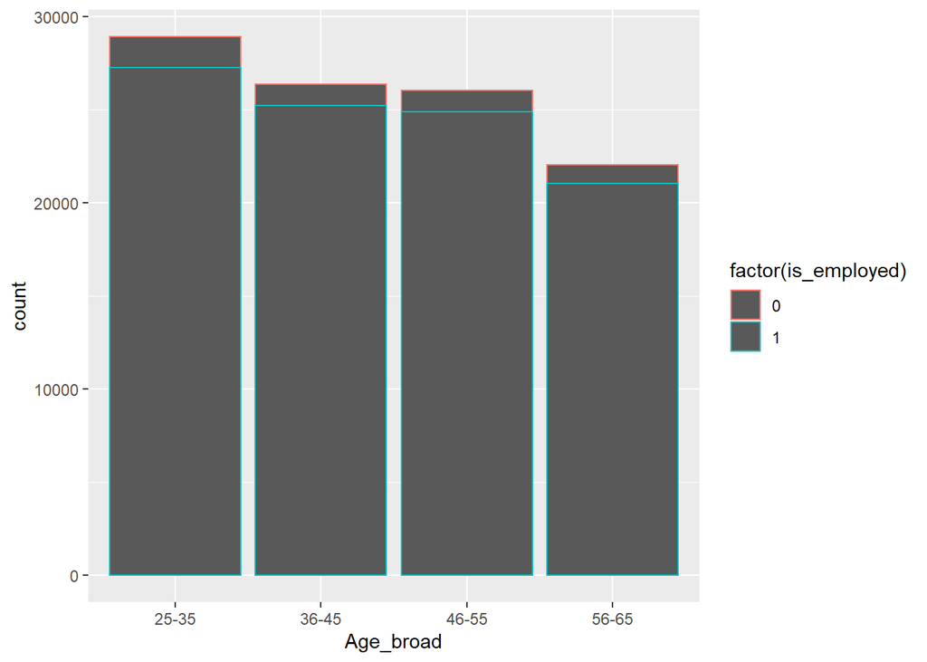

```r
ggplot(df, aes(x= Age_broad, color = factor(is_employed))) + geom_bar()
```

$Note:$: Age shows no large discrepancies, with employment.

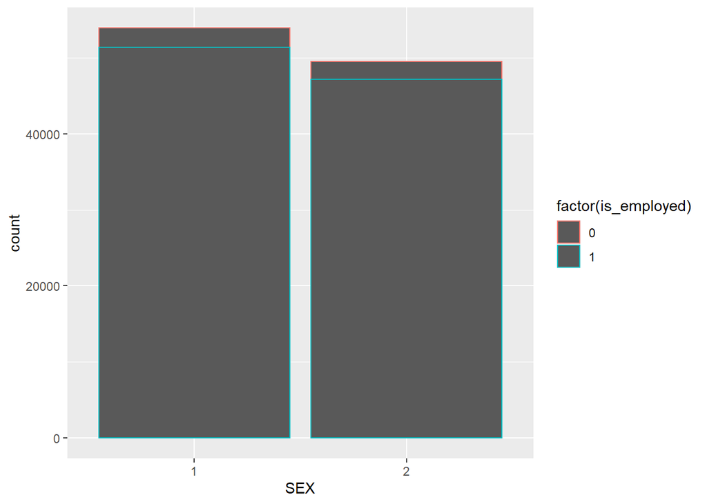

```r
ggplot(df, aes(x= SEX, color = factor(is_employed))) + geom_bar()
```

$Note:$: Sex shows no large discrepancies, with employment.

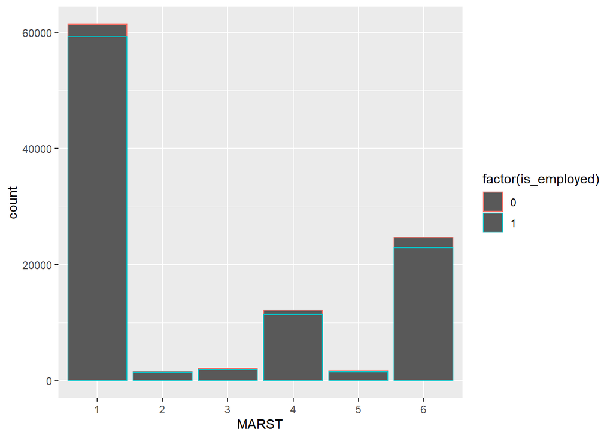

```r
ggplot(df, aes(x= MARST, color = factor(is_employed))) + geom_bar()
```

$Note:$: Marital status shows no large discrepancies, with employment.

The above analysis looks at pre and post covid together so next I want to look at our data and the employment change overtime.

### *Drop in total employment*

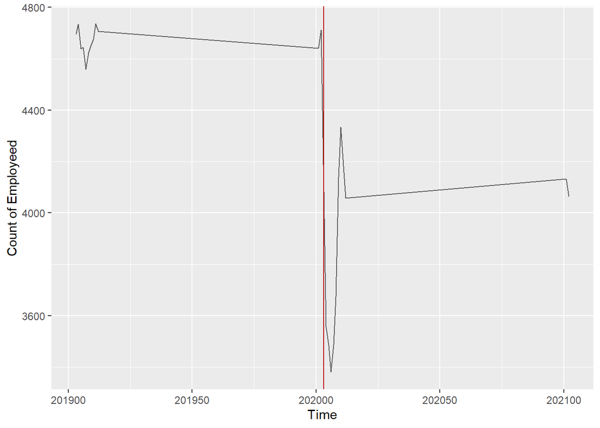

```r
agg <- df %>%
  group_by(yearmo) %>%
  summarise(employed_count = sum(as.numeric(is_employed))) %>%
  arrange(., yearmo)

ggplot(data=agg, aes(y = employed_count, x = yearmo))+
  geom_line(alpha = 0.6)+
  geom_vline(xintercept = 202003, colour="#BB0000")+
  labs(y = 'Count of Employeed', x = 'Time')
```

$Note:$ The large fall right after the start of covid followed by a large uptick a few months later. ***

Do to the volatility and scale I also want to look at the employment variation as % changes to capture a more normalized metric. ### *By percentage change to normalize the change*

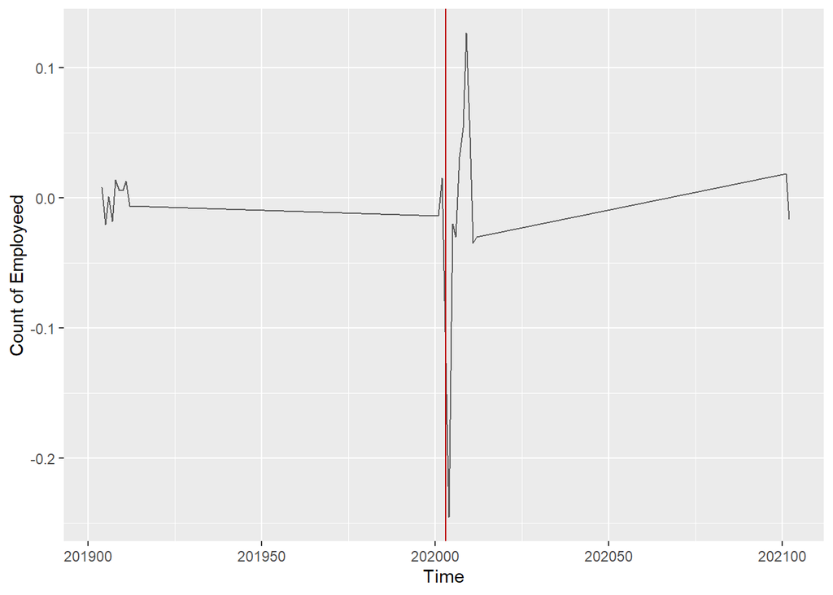

```r
agg <- df %>%
  group_by(yearmo) %>%
  summarise(employed_count = sum(as.numeric(is_employed))) %>%
  arrange(., yearmo)

agg <- agg %>%
  mutate(lag1_value = lag(employed_count, n=1, order_by=yearmo)) %>%
  mutate(prc_change_emp = (employed_count-lag1_value)/ lag1_value)

ggplot(data=agg, aes(y = prc_change_emp , x = yearmo))+
  geom_line(alpha = 0.6)+
  geom_vline(xintercept = 202003, colour="#BB0000")+
  labs(y = 'Count of Employeed', x = 'Time')
```

# Employment before and after covid

In this section we want to look at how employment numbers and the % change in employment fluctuates after covid

### *Drop by Race*

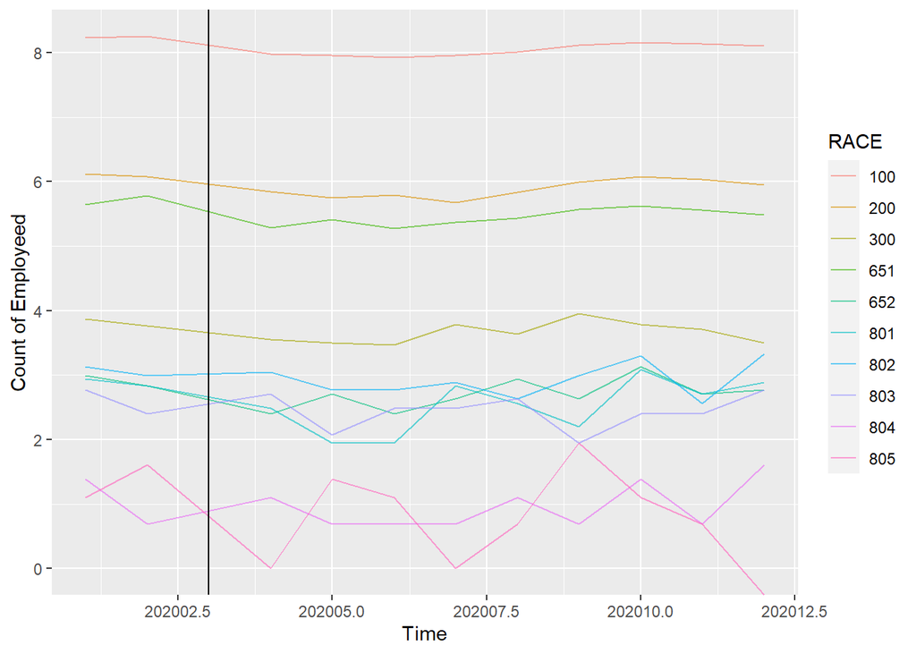

```r
agg <- df %>%
  group_by(yearmo, RACE) %>%
  summarise(employed_count = sum(as.numeric(is_employed))) %>%
  filter(yearmo >= 201950) %>%
  filter(yearmo <= 202020) %>%
  arrange(.,RACE, yearmo)

ggplot(data=agg, aes(y = log(employed_count), x = yearmo))+
  geom_line(alpha = 0.6, aes(color = factor(RACE)))+
  geom_vline(xintercept = 202003)+
  labs(y = 'Count of Employeed', x = 'Time', color = 'RACE')
```

$Note:$ Most races show about a similar level of employment drop, however some races in terms of over all count are more or less employed to begin with, so a similar drop in employment numbers across race might not really be proportional impacts.

So to examine this in more detail lets look at the the % change overtime by race.

### *% Drop by RACE*

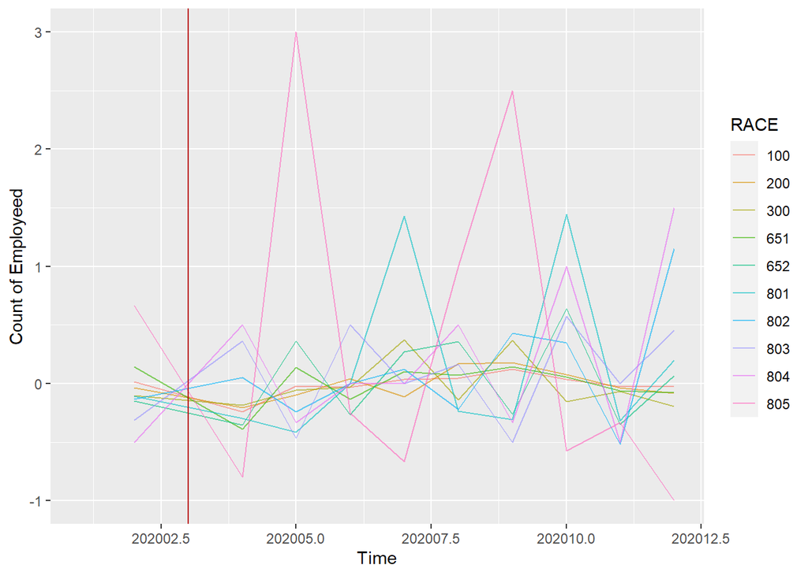

$Note:$ While some races stay relatively steady and correlated to each other, others show high fluctuations. *Some of these are also races with small sample size so a 1 person change in employment makes a large delta in this graph*.

### *Drop by indname*

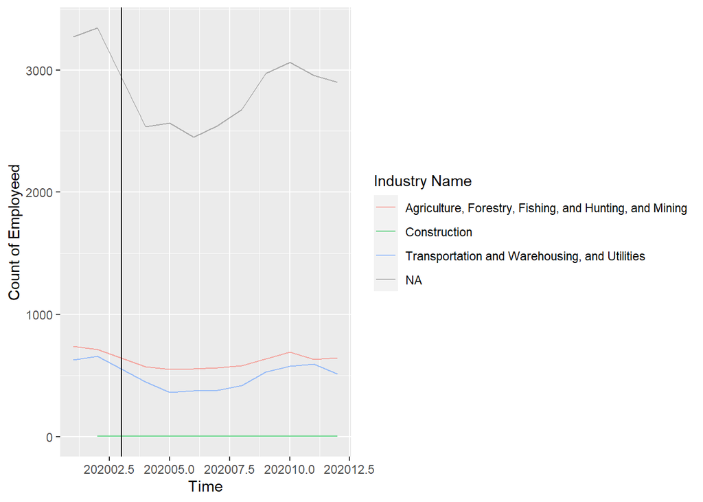

```r
agg <- df %>%
  group_by(yearmo, indname) %>%
  summarise(employed_count = sum(as.numeric(is_employed))) %>%
  filter(yearmo >= 201950) %>%
  filter(yearmo <= 202020) %>%
  arrange(.,indname, yearmo)

ggplot(data=agg, aes(y = employed_count, x = yearmo))+
  geom_line(alpha = 0.6, aes(color = factor(indname)))+
  geom_vline(xintercept = 202003)+
  labs(y = 'Count of Employeed', x = 'Time', color = 'Industry Name')
```

$Note:$ That NA takes a majority representation in our data set and constructions takes a very small sample set. This industry type field looks to have quality errors, due to the large amount of N/A values. (majority of this industry data is actually unknown so we may not use this in modeling)

### *% Drop by indname*

Taking a look by industry type

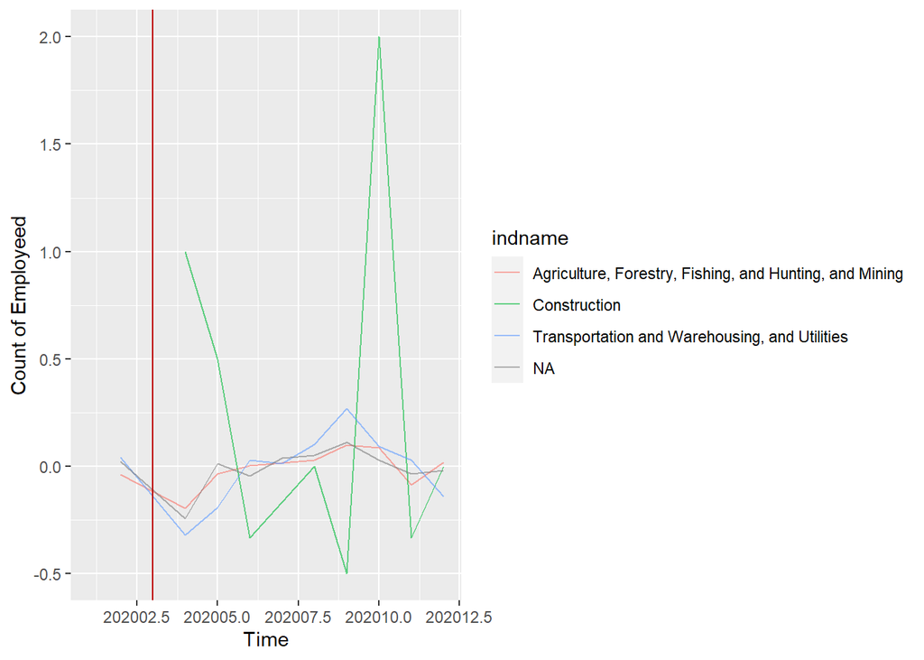

```r
agg <- df %>%
  group_by(yearmo, indname) %>%
  summarise(employed_count = sum(as.numeric(is_employed))) %>%
  filter(yearmo >= 201950) %>%
  filter(yearmo <= 202020) %>%
  arrange(., yearmo)

agg <- agg %>%
  group_by(indname) %>%
  mutate(lag1_value = lag(employed_count, n=1, order_by= yearmo)) %>%
  mutate(prc_change_emp = (employed_count-lag1_value)/ lag1_value) %>%
  arrange(., indname, yearmo)

ggplot(data=agg, aes(y = prc_change_emp, x = yearmo))+
  geom_line(alpha = 0.6, aes(color = factor(indname)))+
  geom_vline(xintercept = 202003, colour="#BB0000")+
  labs(y = 'Count of Employeed', x = 'Time', color = 'indname')
```

$Note:$ This graph shows a more normalized representation of each industry. Assuming that `NA` is a catch all for anything that’s not `Agriculture, Forestry, etc`, or `Construction`, or `Transportation` NA would serve as the market indicator representing all other jobs aside from the ones listed here. If we use industry `NA` as the market norm across industries we can see that Transportation and Agriculture follow the overall market employment trend pretty closely, however constructions does not. This might indicate that Transportation and Agriculture do not systematically differ from that of other job types in terms of the covid impact on employment.

*Construction though also has a very small sample size, so a small change in the number employed can make the % change look more sever than it is (which is the case here*

### *Drop by age group*

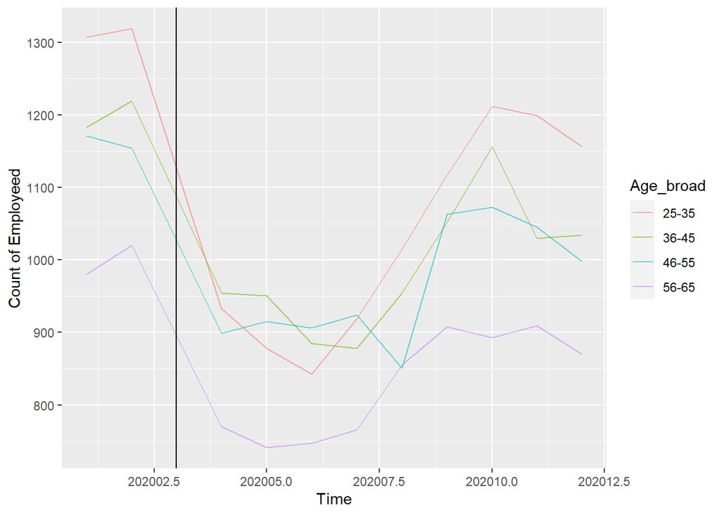

```r
agg <- df %>%
  group_by(yearmo,Age_broad) %>%
  summarise(employed_count = sum(as.numeric(is_employed))) %>%
  filter(yearmo >= 201950) %>%
  filter(yearmo <= 202020) %>%
  arrange(.,Age_broad, yearmo)

ggplot(data=agg, aes(y = employed_count, x = yearmo))+
  geom_line(alpha = 0.6, aes(color = factor(Age_broad)))+
  geom_vline(xintercept = 202003)+
  labs(y = 'Count of Employeed', x = 'Time', color = 'Age_broad')
```

### *% Drop by age group*

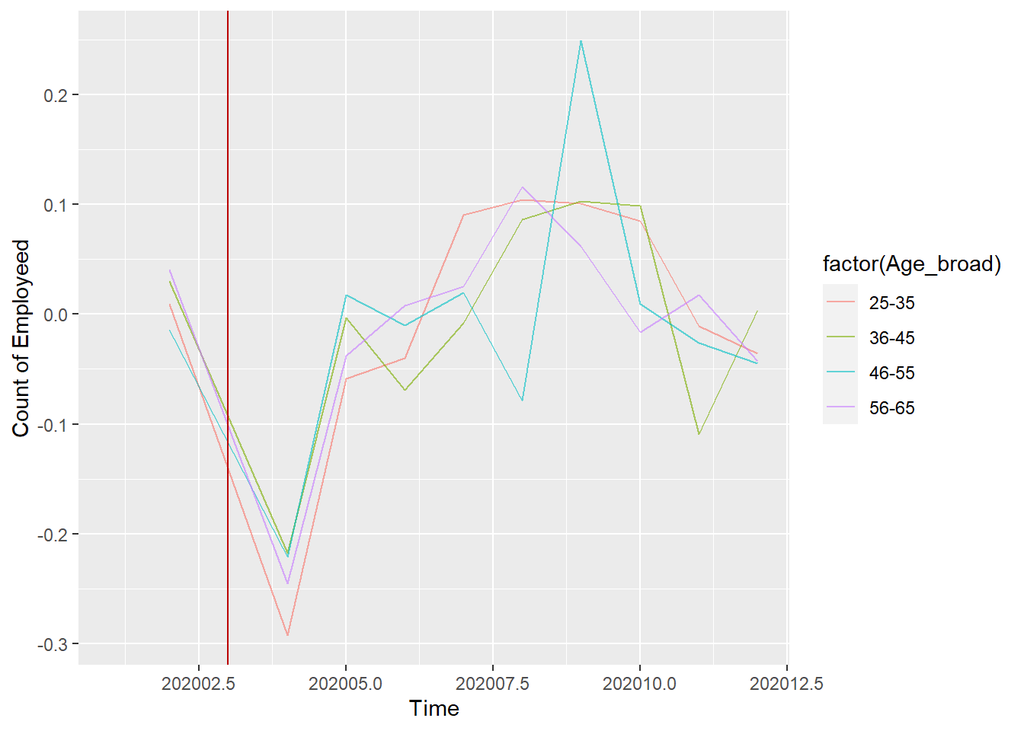

```r
agg <- df %>%
  group_by(yearmo, Age_broad) %>%
  summarise(employed_count = sum(as.numeric(is_employed))) %>%
  filter(yearmo >= 201950) %>%
  filter(yearmo <= 202020) %>%
  arrange(., yearmo)

agg <- agg %>%
  group_by(Age_broad) %>%
  mutate(lag1_value = lag(employed_count, n=1, order_by= yearmo)) %>%
  mutate(prc_change_emp = (employed_count-lag1_value)/ lag1_value) %>%
  arrange(., Age_broad, yearmo)

ggplot(data=agg, aes(y = prc_change_emp, x = yearmo))+
  geom_line(alpha = 0.6, aes(color = factor(Age_broad)))+
  geom_vline(xintercept = 202003, colour="#BB0000")+
  labs(y = 'Count of Employeed', x = 'Time')
```

$Note:$ After looking at the age groups graphs by count and % we can see that the change across age groups seems to be highly correlated to each other, indicating that one age group does not behave systematically different than that of another.

### *Drop by sex*

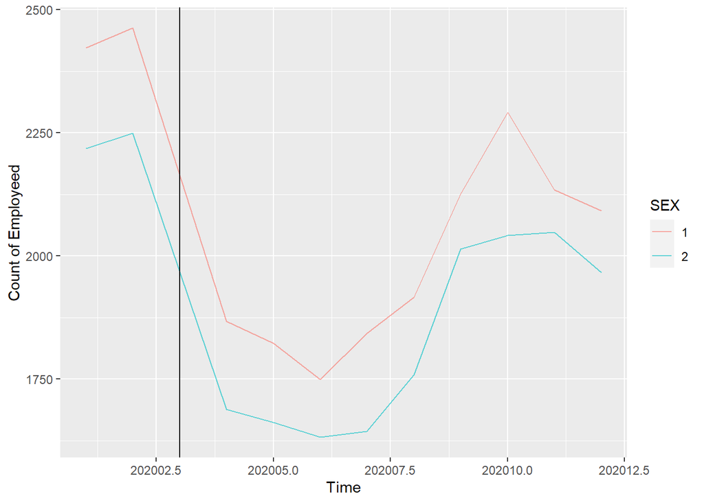

```r
agg <- df %>%
  group_by(yearmo,SEX) %>%
  summarise(employed_count = sum(as.numeric(is_employed))) %>%
  filter(yearmo >= 201950) %>%
  filter(yearmo <= 202020) %>%
  arrange(.,SEX, yearmo)

ggplot(data=agg, aes(y = employed_count, x = yearmo))+
  geom_line(alpha = 0.6, aes(color = factor(SEX)))+
  geom_vline(xintercept = 202003)+
  labs(y = 'Count of Employeed', x = 'Time', color = 'SEX')
```

# *% Drop by sex*

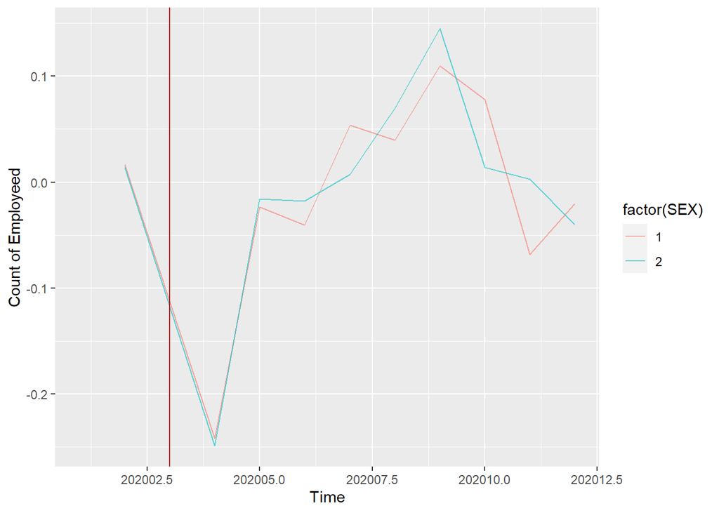

```r
agg <- df %>%
  group_by(yearmo, SEX) %>%
  summarise(employed_count = sum(as.numeric(is_employed))) %>%
  filter(yearmo >= 201950) %>%
  filter(yearmo <= 202020) %>%
  arrange(., yearmo)

agg <- agg %>%
  group_by(SEX) %>%
  mutate(lag1_value = lag(employed_count, n=1, order_by= yearmo)) %>%
  mutate(prc_change_emp = (employed_count-lag1_value)/ lag1_value) %>%
  arrange(., SEX, yearmo)

ggplot(data=agg, aes(y = prc_change_emp, x = yearmo))+
  geom_line(alpha = 0.6, aes(color = factor(SEX)))+
  geom_vline(xintercept = 202003, colour="#BB0000")+
  labs(y = 'Count of Employeed', x = 'Time')
```

$Note:$ Employment change across sex is also correlated to each other indicating that one group does not behave systematically different than that of another.

### _ Drop by marital status_

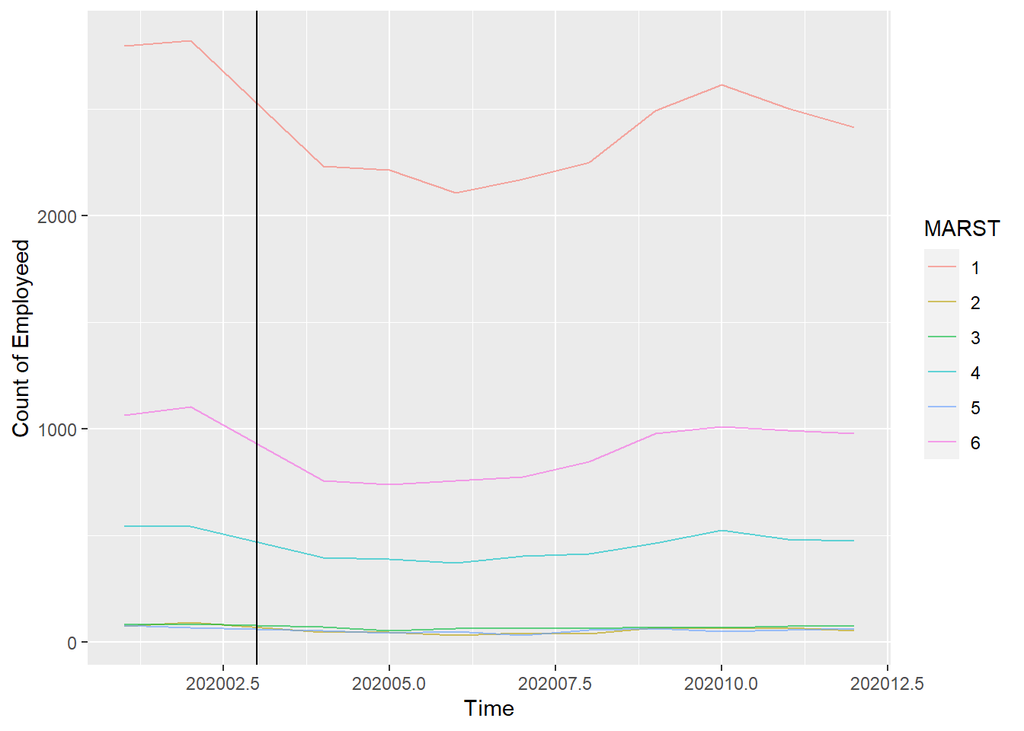

```r
agg <- df %>%
  group_by(yearmo, MARST) %>%
  summarise(employed_count = sum(as.numeric(is_employed))) %>%
  filter(yearmo >= 201950) %>%
  filter(yearmo <= 202020) %>%
  arrange(.,MARST, yearmo)

ggplot(data=agg, aes(y = employed_count, x = yearmo))+
  geom_line(alpha = 0.6, aes(color = factor(MARST)))+
  geom_vline(xintercept = 202003)+
  labs(y = 'Count of Employeed', x = 'Time', color = 'MARST')
```

### *% Drop by marital status*

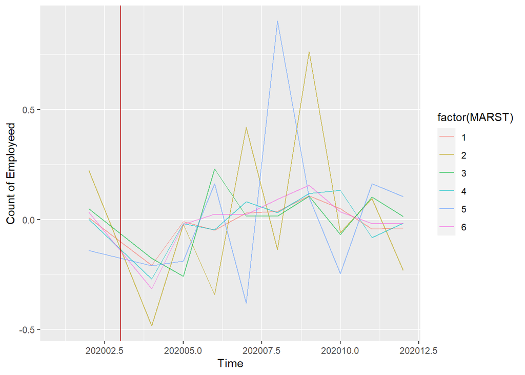

```r
agg <- df %>%
  group_by(yearmo, MARST) %>%
  summarise(employed_count = sum(as.numeric(is_employed))) %>%
  filter(yearmo >= 201950) %>%
  filter(yearmo <= 202020) %>%
  arrange(., yearmo)

agg <- agg %>%
  group_by(MARST) %>%
  mutate(lag1_value = lag(employed_count, n=1, order_by= yearmo)) %>%
  mutate(prc_change_emp = (employed_count-lag1_value)/ lag1_value) %>%
  arrange(., MARST, yearmo)

ggplot(data=agg, aes(y = prc_change_emp, x = yearmo))+
  geom_line(alpha = 0.6, aes(color = factor(MARST)))+
  geom_vline(xintercept = 202003, colour="#BB0000")+
  labs(y = 'Count of Employeed', x = 'Time')
```

Based on the SEX, AGE graphical relationship we can see that they move in sync, marital status however has more variation in select statuses. Due to these findings I’m selecting not to explore Age and sex variables in the model.

# Modeling

### *binary effects (no interaction term)*

The below models show simple linear models with factor variables. This model does *NOT* look at pre and post covid differences, it is simply looking at the factor’s coefficients on employment as it applies to both pre and post covid.

```r
lpm1 <- feols(is_employed ~ factor(RACE) + factor(SEX) + factor(Age_broad) + factor(MARST) + factor(Education),
              data = df, se='hetero')

etable(lpm1, digits = 3)
```

```
##                                                 lpm1
## Dependent Var.:                          is_employed
##
## (Intercept)                         0.968*** (0.002)
## factor(RACE)200                    -0.019*** (0.003)
## factor(RACE)300                    -0.041*** (0.008)
## factor(RACE)651                    -0.011*** (0.003)
## factor(RACE)652                      -0.0007 (0.010)
## factor(RACE)801                       -0.012 (0.012)
## factor(RACE)802                       -0.008 (0.010)
## factor(RACE)803                       -0.010 (0.013)
## factor(RACE)804                       -0.024 (0.029)
## factor(RACE)805                      -0.080* (0.038)
## factor(SEX)2                          -0.002 (0.001)
## factor(Age_broad)36-45               0.005** (0.002)
## factor(Age_broad)46-55                0.004* (0.002)
## factor(Age_broad)56-65                0.003. (0.002)
## factor(MARST)2                       -0.012* (0.006)
## factor(MARST)3                     -0.040*** (0.006)
## factor(MARST)4                     -0.017*** (0.002)
## factor(MARST)5                     -0.021*** (0.006)
## factor(MARST)6                     -0.032*** (0.002)
## factor(Education)doctorate          0.021*** (0.003)
## factor(Education)highschoolorlower -0.019*** (0.002)
## factor(Education)NA                 0.013*** (0.002)
## __________________________________ _________________
## S.E. type                          Heteroskeda.-rob.
## Observations                                 103,422
## R2                                           0.01030
## Adj. R2                                      0.01009
## ---
## Signif. codes: 0 '***' 0.001 '**' 0.01 '*' 0.05 '.' 0.1 ' ' 1
```

*Interpretation*:

## Predicted values

### *RACE*

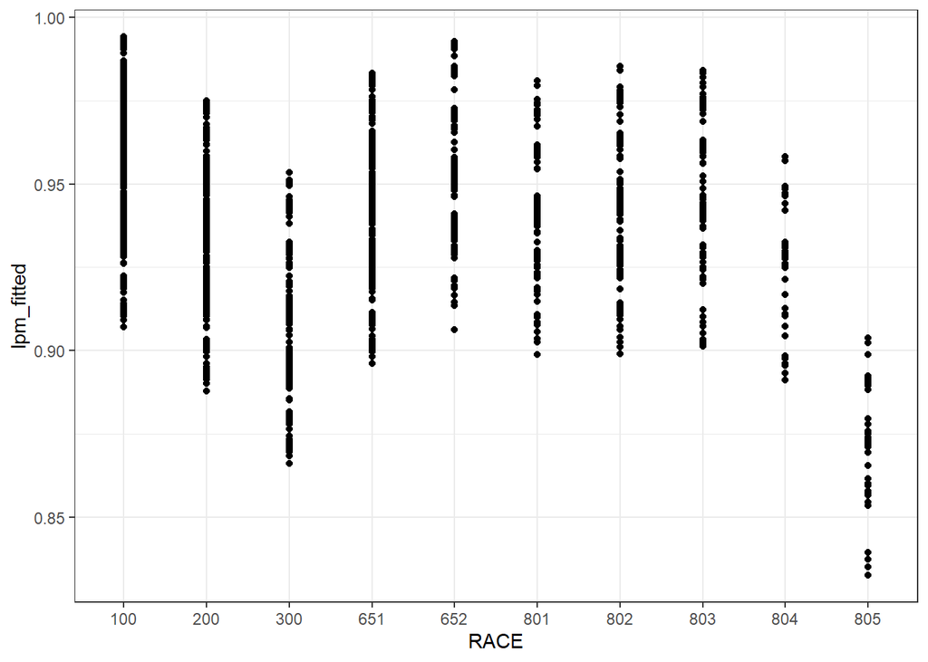

```r
df <- df %>%
  mutate(lpm_fitted = predict(lpm1))

ggplot(data = df, mapping = aes(x=RACE, y=lpm_fitted))+
  geom_point()+
  geom_smooth(color = 'red', se=FALSE)+
  theme_bw()
```

$Note:$ This graph shows the predicted value for each race category for both pre and post covid. Notice that certain races are have a lower predicted likelihood for employment status.

### *Education*

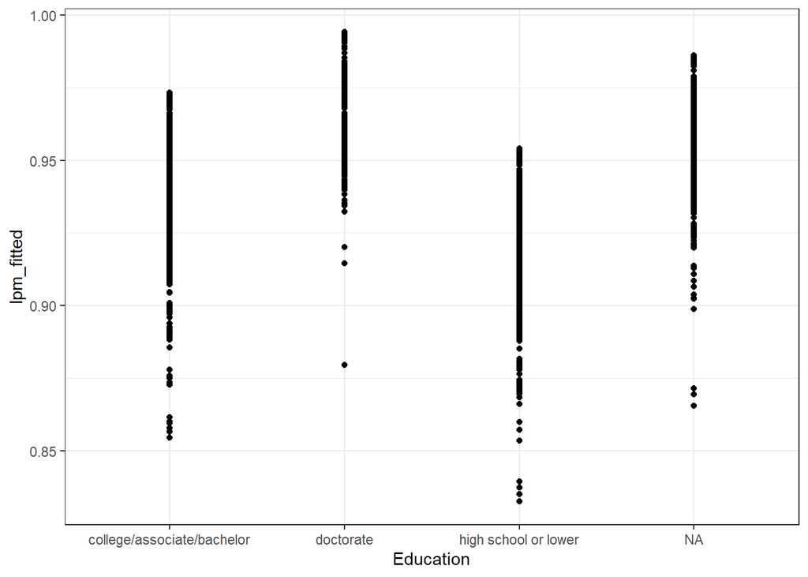

```r
ggplot(data = df, mapping = aes(x=Education, y=lpm_fitted))+
  geom_point()+
  geom_smooth(color = 'red', se=FALSE)+
  theme_bw()
```

$Note:$ A large difference in doctorate level but not a huge difference between high school and undergrad in terms of predicted employment status.

### *MARST*

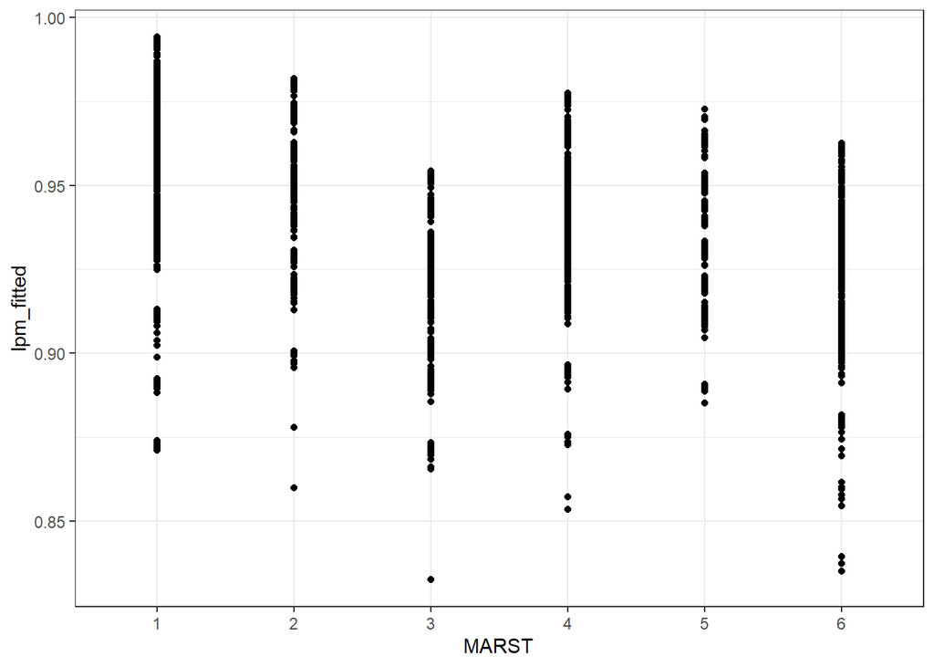

```r
ggplot(data = df, mapping = aes(x=MARST, y=lpm_fitted))+
  geom_point()+
  geom_smooth(color = 'red', se=FALSE)+
  theme_bw()
```

$Note:$ Fairly constant predictive value across marital status but notice that “1” (married spouse present) have the highest predicted value and “3” (separated) and “6” (single) have the lowest predicted probability.

### Modeling with interaction term

Make dummy for education

```r
lpm3 <- feols(is_employed ~ is_post + Education, data = df, se='hetero')
lpm4 <- feols(is_employed ~  is_post + Education + is_post:Education, data = df, se='hetero')
etable(lpm3,lpm4)
```

```
##                                                         lpm3
## Dependent Var.:                                  is_employed
##
## (Intercept)                               0.9747*** (0.0009)
## is_postTRUE                              -0.0414*** (0.0014)
## Educationdoctorate                        0.0261*** (0.0028)
## Educationhighschoolorlower               -0.0213*** (0.0016)
## EducationNA                               0.0157*** (0.0017)
## is_postTRUE x Educationdoctorate
## is_postTRUE x Educationhighschoolorlower
## is_postTRUE x EducationNA
## ________________________________________ ___________________
## S.E. type                                Heteroskedast.-rob.
## Observations                                         103,422
## R2                                                   0.01300
## Adj. R2                                              0.01297
##
##                                                         lpm4
## Dependent Var.:                                  is_employed
##
## (Intercept)                               0.9736*** (0.0009)
## is_postTRUE                              -0.0389*** (0.0018)
## Educationdoctorate                        0.0181*** (0.0027)
## Educationhighschoolorlower               -0.0134*** (0.0017)
## EducationNA                               0.0062*** (0.0019)
## is_postTRUE x Educationdoctorate           0.0167** (0.0058)
## is_postTRUE x Educationhighschoolorlower -0.0183*** (0.0034)
## is_postTRUE x EducationNA                 0.0206*** (0.0034)
## ________________________________________ ___________________
## S.E. type                                Heteroskedast.-rob.
## Observations                                         103,422
## R2                                                   0.01390
## Adj. R2                                              0.01383
## ---
## Signif. codes: 0 '***' 0.001 '**' 0.01 '*' 0.05 '.' 0.1 ' ' 1
```

*Interpretation lpm3*

$Note:$ All of which are statistically significant at the 0.01% leve

*Interpretation lpm4*

This model looks at the interaction term between education and is_post covid.

- The effect of being a doctor vs not being a doctor post covid is 0.0167 indicating that there is a positive 1.67 percentage point increase associated with being a doctor post covid relative to a bachelors.(this is statistically significant at the 0.01% level). This same effect pre-covid was 0.0181 or 1.81% percentage points. Resulting in a -0.14 percentage point covid effect for doctoral employment.
- The effect of being a highschool degree post covid is -0.0183 indicating that there is a -1.83 percentage point effect associated with highschool degree post covid relative to a bachelors.(this is statistically significant at the 0.01% level). This same effect pre-covid was -0.0134 or -1.34% percentage points. Resulting in a -0.49 percentage point covid effect for highschool degrees on employment.

$Note:$ The covid effect on high school degrees is ~ 3X larger of an effect than that of the effect on bachelors degrees or doctoral degrees. This is statistical significant at the **0.1%** level

### *RACE*

```r
lpm10 <- feols(is_employed ~ is_post + RACE + is_post:RACE, data = df, se='hetero')
etable(lpm10)
```

```
##                                     lpm10
## Dependent Var.:               is_employed
##
## (Intercept)            0.9727*** (0.0008)
## is_postTRUE           -0.0368*** (0.0015)
## RACE200               -0.0193*** (0.0029)
## RACE300               -0.0471*** (0.0101)
## RACE651                  0.0054* (0.0026)
## RACE652                   0.0038 (0.0095)
## RACE801                   0.0058 (0.0095)
## RACE802                  -0.0085 (0.0106)
## RACE803                  -0.0021 (0.0130)
## RACE804                   0.0064 (0.0206)
## RACE805                  -0.0409 (0.0380)
## is_postTRUE x RACE200 -0.0186*** (0.0055)
## is_postTRUE x RACE300    -0.0081 (0.0177)
## is_postTRUE x RACE651 -0.0240*** (0.0059)
## is_postTRUE x RACE652    -0.0218 (0.0219)
## is_postTRUE x RACE801   -0.0639* (0.0267)
## is_postTRUE x RACE802    -0.0121 (0.0211)
## is_postTRUE x RACE803    -0.0189 (0.0269)
## is_postTRUE x RACE804    -0.0939 (0.0658)
## is_postTRUE x RACE805    -0.1072 (0.0807)
## _____________________ ___________________
## S.E. type             Heteroskedast.-rob.
## Observations                      103,422
## R2                                0.01177
## Adj. R2                           0.01159
## ---
## Signif. codes: 0 '***' 0.001 '**' 0.01 '*' 0.05 '.' 0.1 ' ' 1
```

*Interpretation lpm10*

This is an identical interpretation as above but for the `RACE` variables relitive to RACE “White”.

- The effect of RACE200 (black) vs RACE100 “White” post covid is -0.0186 indicating that there is a negative -1.86 percentage point decrease associated with being black post covid, relative to being white post covid. (this is statistically significant at the 0.1% level).
- Additionally Race200 (black pre-covid) had a -1.93 percentage point difference compared to Race 100 (white pre-covid).

-The effect of covid on race black there for is -0.07 percentage points lower than that of the effect on white people.

### *Matital Status*

```r
lpm11 <- feols(is_employed ~ is_post + MARST, data = df, se='hetero')
lpm12 <- feols(is_employed ~ MARST + is_post + is_post:MARST, data = df, se='hetero')

etable(lpm11,lpm12)
```

```
##                                    lpm11               lpm12
## Dependent Var.:              is_employed         is_employed
##
## (Intercept)           0.9836*** (0.0008)  0.9808*** (0.0007)
## is_postTRUE          -0.0411*** (0.0014) -0.0348*** (0.0016)
## MARST2               -0.0199*** (0.0058)   -0.0119* (0.0058)
## MARST3               -0.0486*** (0.0061) -0.0340*** (0.0066)
## MARST4               -0.0197*** (0.0022) -0.0180*** (0.0024)
## MARST5               -0.0280*** (0.0059)  -0.0203** (0.0062)
## MARST6               -0.0373*** (0.0018) -0.0288*** (0.0020)
## MARST2 x is_postTRUE                        -0.0189 (0.0126)
## MARST3 x is_postTRUE                      -0.0338** (0.0129)
## MARST4 x is_postTRUE                        -0.0036 (0.0046)
## MARST5 x is_postTRUE                        -0.0186 (0.0130)
## MARST6 x is_postTRUE                     -0.0193*** (0.0038)
## ____________________ ___________________ ___________________
## S.E. type            Heteroskedast.-rob. Heteroskedast.-rob.
## Observations                     103,422             103,422
## R2                               0.01518             0.01564
## Adj. R2                          0.01512             0.01554
## ---
## Signif. codes: 0 '***' 0.001 '**' 0.01 '*' 0.05 '.' 0.1 ' ' 1
```

*Interpretation lmp12*

This model looks at the interaction term between marital status and covid. These results are all relative to MARST = 1 or married with spouce present.

- The effect of having a marital status = 3 (separated) vs status = 1 (married) post covid is -0.0338 indicating that there is a -3.38 percentage point change associated with being separated post covid. (this is statistically significant at the 1% level)
- The coefficient on being separated pre covid is -0.0340 or -3.4 percentage point.
- The effect of covid on separated individuals there for is -0.02 percentage points lower than that of married individuals.

The same observations occurs for MARST 6 (single) as well resulting in a covid effect of -0.95 percentage points less than married individuals. These effects are not substantially different than that of married individuals but results are statistically significant.

# Summary

Based on our analysis of demographics and the effect of covid on each demographic we can conclude there there are select demographic traits that are more impacted than others by covid.

Out of the select demographic variables used for analysis (RACE, Education, and Marital Status) we can conclude that selecvt RACE groups and Education status wre more heaviliy impact by covid.

Race:

Marital Status:

When compared to being married. - The effect of covid on a separated individual was -0.02 percentage points relative to married. - The effect of covid on a single individual was –0.95 percentage points relative to married.

Using employment as a pseudo measure for spending power I would recommend that a retail organization (post covid) focus there retail and marketing strategy on a select demographic as they were less impacted by the effect of covid.This assumes that the retail organization is not soly focused on specific target audience or demographic, and this assumes that the retail organization in mind prefers quantity of customers and is profit seeking. Post covid in the changing market envioronment i would receomdn a focused attention to induviduals who were less impacted by covid, those individuals typically being well educated, white, and married as they tended to be less harmed by the effects of covid in terms of employment.